# **Milestone 1**

## **Data Description**

There are a total of 24,958 train and 2,600 test images (colored) that we have taken from microscopic images. These images are of the following categories:

**Parasitized:** The parasitized cells contain the Plasmodium parasite which causes malaria  
**Uninfected:** The uninfected cells are free of the Plasmodium parasites

## **Important Notes**

- This notebook can be considered a guide to refer to while solving the problem. The evaluation will be as per the Rubric shared for each Milestone. Unlike previous courses, it does not follow the pattern of the graded questions in different sections. This notebook would give you a direction on what steps need to be taken in order to get a viable solution to the problem. Please note that this is just one way of doing this. There can be other 'creative' ways to solve the problem and we urge you to feel free and explore them as an 'optional' exercise.
- In the notebook, there are markdowns cells called - Observations and Insights. It is a good practice to provide observations and extract insights from the outputs.
- The naming convention for different variables can vary. Please consider the code provided in this notebook as a sample code.
- All the outputs in the notebook are just for reference and can be different if you follow a different approach.
- There are sections called **Think About It** in the notebook that will help you get a better understanding of the reasoning behind a particular technique/step. Interested learners can take alternative approaches if they want to explore different techniques.

### **Mounting the Drive**

```python
#Mounting the drive
from google.colab import drive
drive.mount('/content/drive')
```

### **Loading libraries**

```python
#Importing libraries required to load the data

import zipfile
import os
from PIL import Image
import numpy as np
import pandas as pd
import matplotlib.pyplot as plt
import seaborn as sns

from sklearn.model_selection import train_test_split
from sklearn.preprocessing import MinMaxScaler

import tensorflow as tf
from tensorflow.keras.models import Sequential
from tensorflow.keras.layers import Dense, Conv2D, MaxPool2D, BatchNormalization, Dropout, Flatten, LeakyReLU, GlobalAvgPool2D
from tensorflow.keras.utils import to_categorical
from tensorflow.keras import optimizers

#to ignore warnings
import warnings
warnings.filterwarnings('ignore')

# Remove the limit from the number of displayed columns and rows. It helps to see the entire dataframe while printing it
pd.set_option("display.max_columns", None)
pd.set_option("display.max_rows", 200)
```

### **Let us load the data**

**Note:**

- You must download the dataset from the link provided on Olympus and upload the same on your Google drive before executing the code in the next cell.
- In case of any error, please make sure that the path of the file is correct as the path may be different for you.

```python
#Storing the path of the data file from the Google drive
path = '/content/drive/MyDrive/Data/cell_images.zip'

#The data is provided as a zip file so we need to extract the files from the zip file
with zipfile.ZipFile(path, 'r') as zip_ref:
    zip_ref.extractall()
```

The extracted folder has different folders for train and test data which further contains the different sizes of images for parasitized and uninfected cells within the respective folder name.

The size of all images must be the same and should be converted to 4D arrays so that they can be used as an input for the convolutional neural network. Also, we need to create the labels for both types of images to be able to train and test the model.

Let's do the same for the training data first and then we will use the same code for the test data as well.

```python
#Storing the path of the extracted "train" folder
train_dir = '/content/cell_images/train'

#Size of image so that each image has the same size
SIZE = 64

#Empty list to store the training images after they are converted to NumPy arrays
train_images = []

#Empty list to store the training labels (0 - uninfected, 1 - parasitized)
train_labels = []
```

```python
#We will run the same code for "parasitized" as well as "uninfected" folders within the "train" folder
for folder_name in ['/parasitized/', '/uninfected/']:

    #Path of the folder
    images_path = os.listdir(train_dir + folder_name)

    for i, image_name in enumerate(images_path):
        try:
            #Opening each image using the path of that image
            image = Image.open(train_dir + folder_name + image_name)

            #Resizing each image to (224,224)
            image = image.resize((SIZE, SIZE))

            #Converting images to arrays and appending that array to the empty list defined above
            train_images.append(np.array(image))

            #Creating labels for parasitized and uninfected images
            if folder_name=='/parasitized/':
                train_labels.append(1)
            else:
                train_labels.append(0)
        except Exception:
            pass

#Converting lists to arrays
train_images = np.array(train_images)
train_labels = np.array(train_labels)
```

```python
#Storing the path of the extracted "test" folder
test_dir = '/content/cell_images/test'

#Size of image so that each image has the same size (it must be same as the train image size)
SIZE = 64

#Empty list to store the testing images after they are converted to NumPy arrays
test_images = []

#Empty list to store the testing labels (0 - uninfected, 1 - parasitized)
test_labels = []
```

```python
#We will run the same code for "parasitized" as well as "uninfected" folders within the "test" folder
for folder_name in ['/parasitized/', '/uninfected/']:

    #Path of the folder
    images_path = os.listdir(test_dir + folder_name)

    for i, image_name in enumerate(images_path):
        try:
            #Opening each image using the path of that image
            image = Image.open(test_dir + folder_name + image_name)

            #Resizing each image to (128,128)
            image = image.resize((SIZE, SIZE))

            #Converting images to arrays and appending that array to the empty list defined above
            test_images.append(np.array(image))

            #Creating labels for parasitized and uninfected images
            if folder_name=='/parasitized/':
                test_labels.append(1)
            else:
                test_labels.append(0)
        except Exception:
            pass

#Converting lists to arrays
test_images = np.array(test_images)
test_labels = np.array(test_labels)
```

### **Checking the shape of train and test images**

```python
# shape of images
print(train_images.shape)
print(test_images.shape)
```

```
(24958, 64, 64, 3)
(2600, 64, 64, 3)
```

### **Checking the shape of train and test labels**

```python
# shape of labels
print(train_labels.shape)
print(test_labels.shape)
```

```
(24958,)
(2600,)
```

### **Check the minimum and maximum range of pixel values for train and test images**

```python
# try to use min and max function from numpy
print(train_images.min(),train_images.max(),np.count_nonzero(np.isnan(train_images)))
print(test_images.min(),test_images.max(),np.count_nonzero(np.isnan(test_images)))
```

```
0 255 0
0 255 0
```

##### **Observations and insights:**

- Each image is 64x64x3 where the 3 RBG values range between 0-255.
- There are no missing values in either the train or test dataset

### **Count the number of values in both uninfected and parasitized**

```python
# try to use value_counts to count the values
# Note: value_counts require using a pandas dataframe, I use an alternative numpy method
for ilabel,iname in zip([train_labels,test_labels],['train','test']):
  a=np.count_nonzero(ilabel==0)
  b=np.count_nonzero(ilabel==1)
  c=a+b
  print(iname+': counts of uninfected, parazited=',a,',',b,' (',round(a/c*100),'%,',round(b/c*100),'%)')
```

```
train: counts of uninfected, parazited= 12479 , 12479  ( 50 %, 50 %)
test: counts of uninfected, parazited= 1300 , 1300  ( 50 %, 50 %)
```

### **Normalize the images**

```python
# try to normalize the train and test images by dividing it by 255 and convert them to float32 using astype function
# Note: we could also have used MinMaxScaler
train_images = (train_images/255).astype('float32')
test_images = (test_images/255).astype('float32')
print(train_images.min(),train_images.max(),np.count_nonzero(np.isnan(train_images)))
print(test_images.min(),test_images.max(),np.count_nonzero(np.isnan(test_images)))
```

```
0.0 1.0 0
0.0 1.0 0
```

##### **Observations and insights:**

- For each image, we have scaled the RGB values to range between 0 and 1.
- The train and test datasets have a perfect 50/50% split between uninfected and parasitized cases. There is no data imbalance.

### **Plot to check if the data is balanced**

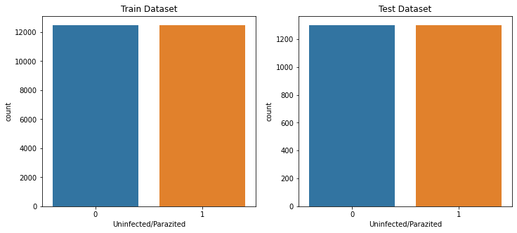

```python
# you are free to use bar plot or pie-plot or count plot, etc. to plot the labels of train and test data and check if they are balanced


fig, (ax1,ax2) =plt.subplots(1,2,figsize=(12,5))
sns.countplot(train_labels, ax=ax1)
sns.countplot(test_labels, ax=ax2)
ax1.title.set_text('Train Dataset')
ax2.title.set_text('Test Dataset')
ax1.set_xlabel('Uninfected/Parazited')
ax2.set_xlabel('Uninfected/Parazited')
fig.show()
```

##### **Observations and insights:**

- The train and test datasets have a perfect 50/50% split between uninfected and parasitzed cases. There is no data imbalance.

### **Data Exploration**

Let's visualize the images from the train data

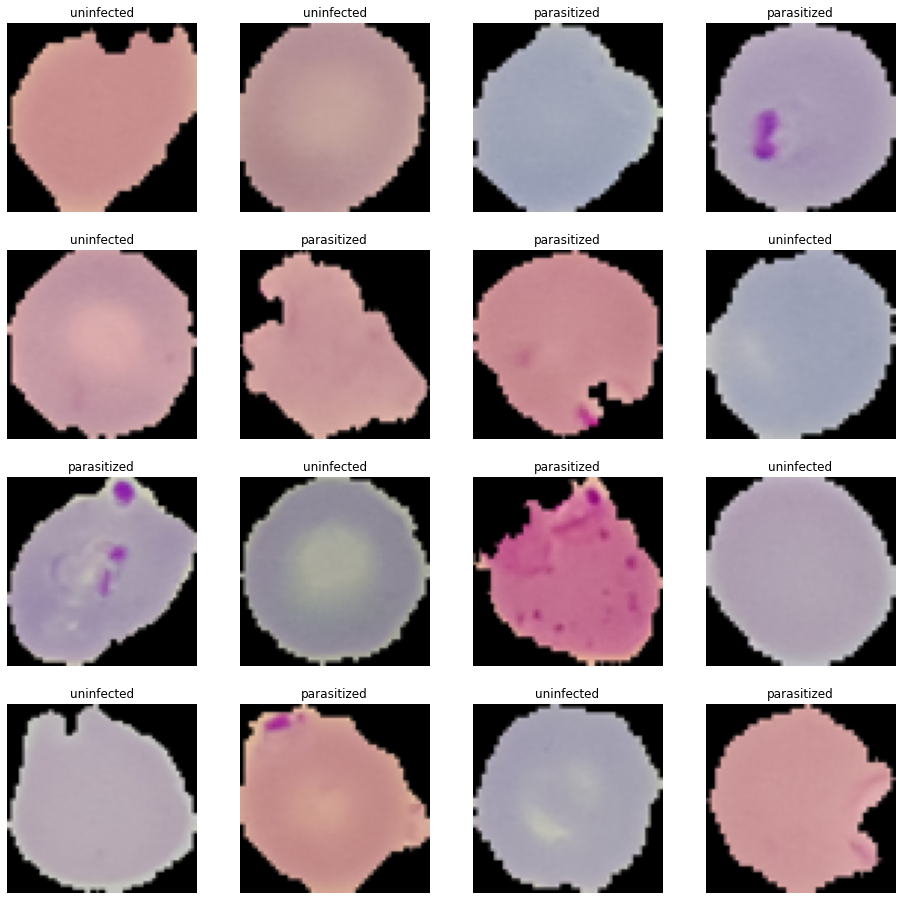

```python
# This code will help you in visualizing both the parasitized and uninfected images
np.random.seed(42)
plt.figure(1 , figsize = (16 , 16))

for n in range(1, 17):
    plt.subplot(4, 4, n)
    index = int(np.random.randint(0, train_images.shape[0], 1))
    if train_labels[index] == 1:
        plt.title('parasitized')
    else:
        plt.title('uninfected')
    plt.imshow(train_images[index])
    plt.axis('off')
```

##### **Observations and insights: **_****

- Each image shows a sample red cell, made to fit rather perfectly within the frame. Color may vary from light pink to light blue regardless of the label (uninfected or parazited).
- Uninfected cells are rather ellipsoidal and uniform. They may sometimes show a lighter center (which is due to the "donut shape" of red cells viewed on a thin blood smear).
- Parazited cells are similar but they contain small bodies (either one or several) of the malaria parasites (technically single-celled microorganisms of the plasmodium type).
- Either uninfected or parasitized cells can looks disformed. This is an artifact of the experimental method which frames images of individual red cells from a blood smear. In reality, both types of cells should be ellipsoidal (except for parasitized cells at the Maurer's clefts life-cycle stage).

### **Similarly visualize the images with subplot(6,6) and figsize=(12,12)**

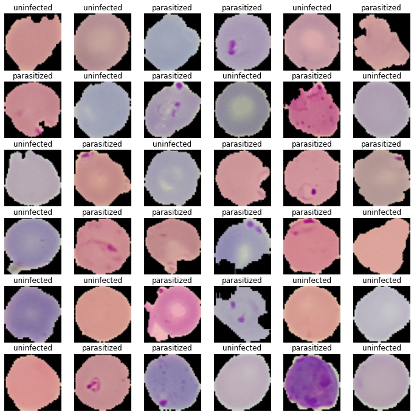

```python
np.random.seed(42)
plt.figure(1 , figsize = (12 , 12))

for n in range(1, 37):
    plt.subplot(6, 6, n)
    index = int(np.random.randint(0, train_images.shape[0], 1))
    if train_labels[index] == 1:
        plt.title('parasitized')
    else:
        plt.title('uninfected')
    plt.imshow(train_images[index])
    plt.axis('off')
```

##### **Observations and insights:**

- Similar conclusions as above. A few more cells look disformed but remember that it is an artifact of the experimental method (it may hinder the predictive potential of our model because of the more complex shapes).

### **Plotting the mean images for parasitized and uninfected**

```python
# function to find the mean
def find_mean_img(full_mat, title):
    # calculate the average
    mean_img = np.mean(full_mat, axis = 0)[0]
    std_img = np.std(full_mat, axis = 0)[0]
    # reshape it back to a matrix
    # plt.imshow(mean_img)
    # plt.title(f'Average {title}')
    # plt.axis('off')
    # plt.show()
    #
    # We modify to plot mean and std
    fig, (ax1,ax2) =plt.subplots(1,2)
    ax1.imshow(mean_img)
    ax2.imshow(std_img)
    ax1.title.set_text(f'Average {title}')
    ax2.title.set_text(f'Std {title}')
    ax1.axis('off')
    ax2.axis('off')
    #
    return mean_img
```

**Mean image for parasitized**

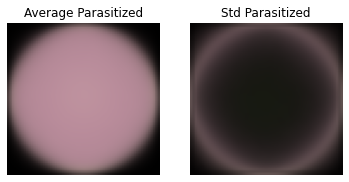

```python
# If the label=1 then the image is parasitised and if the label=0 then the image is uninfected
parasitized_data=[]                                # Create a list to store the parasitized data
for img, label in zip(train_images, train_labels):
        if label==1:
              parasitized_data.append([img])

parasitized_mean = find_mean_img(np.array(parasitized_data), 'Parasitized')   # find the mean
```

**Mean image for uninfected**

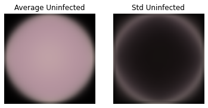

```python
# Similarly write the code to find the mean image of uninfected
uninfected_data=[]
for img, label in zip(train_images, train_labels):
        if label==0:
              uninfected_data.append([img])

uninfected_mean = find_mean_img(np.array(uninfected_data), 'Uninfected')   # find the mean
```

##### **Observations and insights:**

- The image average is a perfect circle. It is identical if computed on either all uninfected or parasitized samples. This is expected because all irregular details are smoothed out by the averaging in either case.
- We have repeated the analysis for standard deviation instead. The std is maximal at the circle edges, because their position varies most from the image framing. The std is identical for uninfected or parasitized samples for the same reasons as the mean.

### **Converting RGB to HSV of Images using OpenCV**

#### **Converting the train data**

```python
import cv2
gfx=[]   # to hold the HSV image array
for i in np.arange(0,100,1):
  a=cv2.cvtColor(train_images[i],cv2.COLOR_BGR2HSV)
  gfx.append(a)
gfx=np.array(gfx)
```

[output not shown]

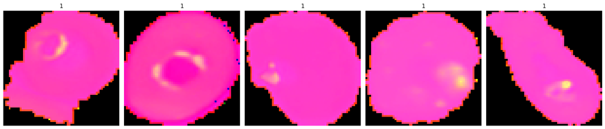

```python
viewimage=np.random.randint(1,100,5)
fig,ax=plt.subplots(1,5,figsize=(18,18))
for t,i in zip(range(5),viewimage):
  Title=train_labels[i]
  ax[t].set_title(Title)
  ax[t].imshow(gfx[i])
  ax[t].set_axis_off()
  fig.tight_layout()
```

#### **Converting the test data**

[output not shown]

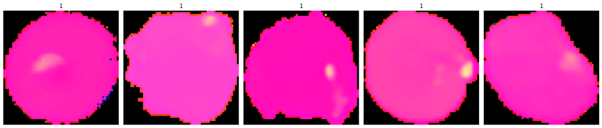

```python
gfxt=[]   # to hold the HSV image array (test data)
for i in np.arange(0,100,1):
  a=cv2.cvtColor(test_images[i],cv2.COLOR_BGR2HSV)
  gfxt.append(a)
gfxt=np.array(gfxt)

viewimage=np.random.randint(1,100,5)
fig,ax=plt.subplots(1,5,figsize=(18,18))
for t,i in zip(range(5),viewimage):
  Title=test_labels[i]
  ax[t].set_title(Title)
  ax[t].imshow(gfxt[i])
  ax[t].set_axis_off()
  fig.tight_layout()
```

##### **Observations and insights: **_****

- Converting the images from RGB to HSV improves the representation of the cells. Cells are typically pink/purple with red borders. When parasitized, the malaria appears as small yellow or blue patterns.
- With better colors, the model may more easily predict parasitized cells (e.g. from the presence of yellow/blue).

#### **Gaussian Blurring on train data**

```python
gbx=[]  ## to hold the blurred images
for i in np.arange(0,100,1):
  b= cv2.GaussianBlur(train_images[i], (5, 5), 0)
  gbx.append(b)
gbx=np.array(gbx)
```

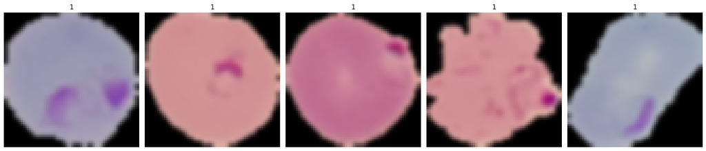

```python
viewimage=np.random.randint(1,100,5)
fig,ax=plt.subplots(1,5,figsize=(18,18))
for t,i in zip(range(5),viewimage):
  Title=train_labels[i]
  ax[t].set_title(Title)
  ax[t].imshow(gbx[i])
  ax[t].set_axis_off()
  fig.tight_layout()
```

#### **Gaussian Blurring on test data**

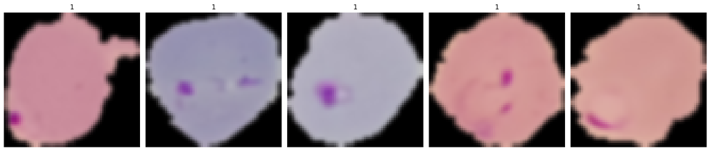

```python
gbxt=[]  ## to hold the blurred images
for i in np.arange(0,100,1):
  b= cv2.GaussianBlur(test_images[i], (5, 5), 0)
  gbxt.append(b)
gbxt=np.array(gbxt)

viewimage=np.random.randint(1,100,5)
fig,ax=plt.subplots(1,5,figsize=(18,18))
for t,i in zip(range(5),viewimage):
  Title=test_labels[i]
  ax[t].set_title(Title)
  ax[t].imshow(gbxt[i])
  ax[t].set_axis_off()
  fig.tight_layout()
```

##### **Observations and insights: **_****

Do you think that blurring would help us for this problem statement in any way?

- It seems unlikely that Gaussian blurring (that smooths image gradients) would be useful. Because we are interested in characterizing the presence of small malaria parasites, we need to detect small edges. If anything, a sharpening filter (which increases image gradients) would be most useful.

## **Proposed approach**

The proposed approach is detailed in the submitted Report of Milestone 1.

## **Additional Analysis**

I add below some additional analysis.

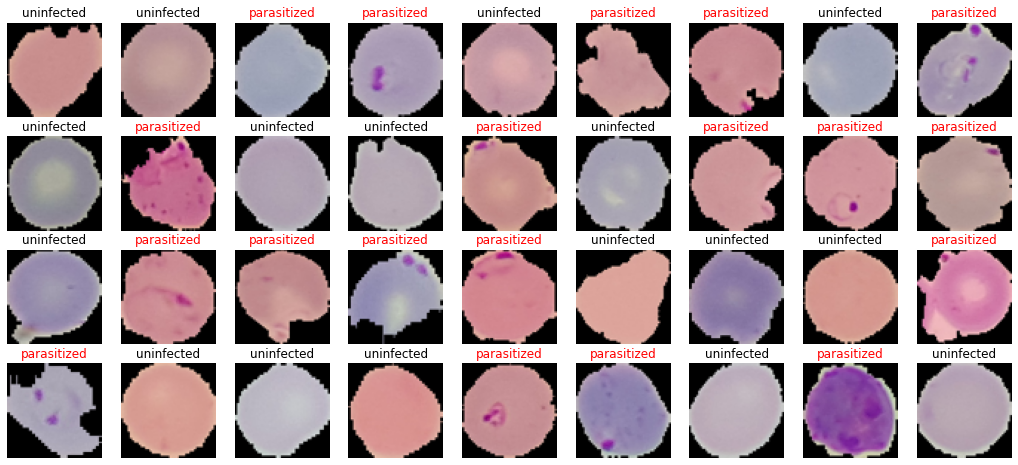

```python
# For the report, same image but larger
np.random.seed(42)
plt.figure(1 , figsize = (18 , 8))

for n in range(1, 37):
    plt.subplot(4, 9, n)
    index = int(np.random.randint(0, train_images.shape[0], 1))
    if train_labels[index] == 1:
        plt.title('parasitized',color='red')
    else:
        plt.title('uninfected')
    plt.imshow(train_images[index])
    plt.axis('off')
```

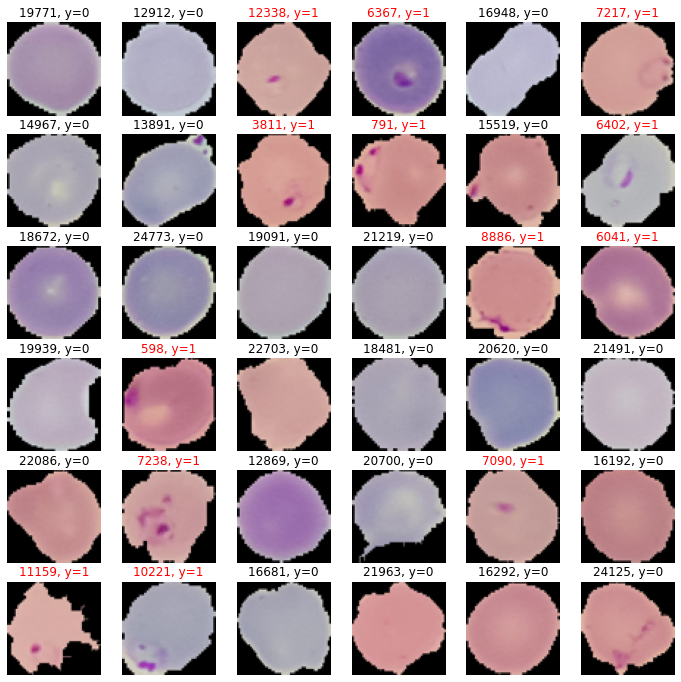

```python
# Visualize a random set of images (with index for later recovery)
np.random.seed()# randomized each time
plt.figure(1 , figsize = (12 , 12))

for n in range(1, 37):
    plt.subplot(6, 6, n)
    index = int(np.random.randint(0, train_images.shape[0], 1))
    if train_labels[index] == 1:
        plt.title(str(index)+', y=1',color='r')
    else:
        plt.title(str(index)+', y=0')
    plt.imshow(train_images[index])
    plt.axis('off')
```

[output not shown]

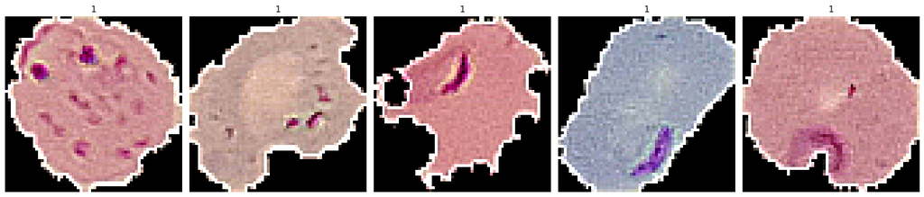

```python
# Test: sharpening on train data using a custom filter kernel
gbx=[]  ## to hold the sharpened images
for i in np.arange(0,100,1):
  kernel = np.array([[-1,-1,-1],
                       [-1, 9,-1],
                       [-1,-1,-1]])
  b= cv2.filter2D(train_images[i], -1, kernel)
  gbx.append(b)
gbx=np.array(gbx)
#
viewimage=np.random.randint(1,100,5)
fig,ax=plt.subplots(1,5,figsize=(18,18))
for t,i in zip(range(5),viewimage):
  Title=train_labels[i]
  ax[t].set_title(Title)
  ax[t].imshow(gbx[i])
  ax[t].set_axis_off()
  fig.tight_layout()
```

[output not shown]

```
(-0.5, 63.5, 63.5, -0.5)
```

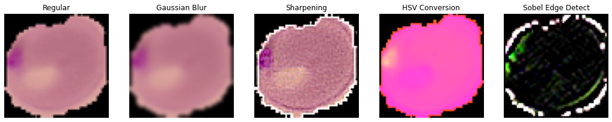

```python
# For the report, put several image filters side by side for a single cell
index=598#

fig,ax=plt.subplots(1,5,figsize=(18,4))
ax[0].imshow(train_images[index])
ax[0].set_title('Regular')
ax[0].axis('off')
#
ax[1].imshow(cv2.GaussianBlur(train_images[index], (5, 5), 0))
ax[1].set_title('Gaussian Blur')
ax[1].axis('off')
#
kernel = np.array([[-1,-1,-1], [-1, 9,-1],[-1,-1,-1]])
ax[2].imshow(cv2.filter2D(train_images[index], -1, kernel))
ax[2].set_title('Sharpening')
ax[2].axis('off')
#
ax[3].imshow(cv2.cvtColor(train_images[index],cv2.COLOR_BGR2HSV))
ax[3].set_title('HSV Conversion')
ax[3].axis('off')
#

ax[4].imshow(cv2.Sobel(train_images[index], ddepth=cv2.CV_64F, dx=1, dy=1, ksize=5))
ax[4].set_title('Sobel Edge Detect')
ax[4].axis('off')
```